# DDoS Botnet Attack Volume Prediction Project

## Introduction

This project explores the prediction of DDoS attack volume using regression techniques on a dataset collected from IoT device attacks. The dataset, ddos_dataset.csv, contains detailed flow-level records with variables such as:

- stime: The start time of a network flow (Unix timestamp).
- flgs_number: Numeric representation of flow state flags.
- proto_number: Numeric representation of the protocol used in the network flow.
- sport: The source port number.
- pkSeqID: A unique identifier for each flow record.

My goal is to aggregate this data on a per-minute basis to compute the attack volume (i.e., the number of flows per minute) and then apply various regression models to predict this volume. This approach will help network administrators anticipate and mitigate potential DDoS attacks.

Regression is a method used to understand and predict how one variable (the target) changes based on other variables (the predictors). In our project, we use linear regression to predict the attack volume (which is the number of flows per minute) using features like flgs_number, proto_number, and sport.

The basic idea behind linear regression can be summed up by this formula:

y = β₀ + β₁x₁ + β₂x₂ + ... + βₙxₙ + ε

Here's what each part means:

y is the value we're trying to predict (in our case, the attack volume). x₁, x₂, ..., xₙ are the input features (for example, flgs_number, proto_number, and sport). β₀ is the intercept, or the value of y when all the x values are zero. β₁, β₂, ..., βₙ are the coefficients that show how much each feature influences y. ε is the error term, which captures the difference between our predictions and the actual observed values. The goal of linear regression is to find the best values for these coefficients so that our predicted values are as close as possible to the actual values. We often measure the performance of our model using Mean Squared Error (MSE), which calculates the average squared difference between predicted and real values. Because MSE is in squared units, we usually take the square root to get the Root Mean Squared Error (RMSE). RMSE gives us an idea of the average prediction error in the same units as our target variable.

In short, linear regression fits a straight line through our data points and tells us how each feature contributes to predicting the outcome.

Lets get started! First we load the dataset containing DDoS flow-level data. The dataset includes fields like `stime` (start time), `flgs_number`, `proto_number`, `sport`, and others.

```python
# Import necessary libraries
import numpy as np
import pandas as pd
import seaborn as sns
import matplotlib.pyplot as plt
from sklearn.model_selection import train_test_split
from sklearn.linear_model import LinearRegression, Ridge
from sklearn.metrics import mean_squared_error
import os

# Ensure plots display inline in Jupyter Notebook
%matplotlib inline

print("Libraries imported successfully!")
```

```
Libraries imported successfully!
```

```python
# Define the dataset file path
file_path = 'ddos_dataset.csv'

# Check if the file exists and load it
if os.path.exists(file_path):
    df = pd.read_csv(file_path, low_memory=False)
    print('Dataset loaded successfully!')
    display(df.head())
else:
    print('Dataset file not found. Please ensure ddos_dataset.csv is in the working directory.')
```

```
Dataset loaded successfully!
```

|  | Unnamed: 0 | pkSeqID | stime | flgs | flgs_number | proto | proto_number | saddr | sport | daddr | ... | AR_P_Proto_P_DstIP | N_IN_Conn_P_DstIP | N_IN_Conn_P_SrcIP | AR_P_Proto_P_Sport | AR_P_Proto_P_Dport | Pkts_P_State_P_Protocol_P_DestIP | Pkts_P_State_P_Protocol_P_SrcIP | attack | category | subcategory |
| --- | --- | --- | --- | --- | --- | --- | --- | --- | --- | --- | --- | --- | --- | --- | --- | --- | --- | --- | --- | --- | --- |
| 0 | 1650261 | 1650261 | 1.528103e+09 | e | 1 | tcp | 1 | 192.168.100.150 | 54110 | 192.168.100.3 | ... | 1.21662 | 40 | 38 | 1.56093 | 1.21662 | 328 | 308 | 1 | DDoS | HTTP |
| 1 | 1650262 | 1650262 | 1.528103e+09 | e | 1 | tcp | 1 | 192.168.100.150 | 54112 | 192.168.100.3 | ... | 1.21662 | 40 | 38 | 1.56107 | 1.21662 | 328 | 308 | 1 | DDoS | HTTP |
| 2 | 1650263 | 1650263 | 1.528103e+09 | e | 1 | tcp | 1 | 192.168.100.150 | 54114 | 192.168.100.3 | ... | 1.21662 | 40 | 38 | 1.24980 | 1.21662 | 328 | 308 | 1 | DDoS | HTTP |
| 3 | 1650264 | 1650264 | 1.528103e+09 | e | 1 | tcp | 1 | 192.168.100.150 | 54116 | 192.168.100.3 | ... | 1.21662 | 40 | 38 | 1.24986 | 1.21662 | 328 | 308 | 1 | DDoS | HTTP |
| 4 | 1650265 | 1650265 | 1.528103e+09 | e | 1 | tcp | 1 | 192.168.100.150 | 54118 | 192.168.100.3 | ... | 1.21662 | 40 | 38 | 1.24991 | 1.21662 | 328 | 308 | 1 | DDoS | HTTP |

5 rows × 47 columns

## Experiment 1: Data Understanding

Before we begin modeling, it's important to get a clear picture of our data. In this step, we:

- Examine the structure of our aggregated dataset.
- Look at summary statistics to understand the data distribution.
- Check for missing values.
- Create a few visualizations to see if any features are correlated or if there are any existing patterns.

These steps help us decide on the best features to use in our first experiment.

[output not shown]

[output not shown]

```
Missing values per column in Aggregated Data:
minute           0
flgs_number      0
proto_number     0
sport            0
attack_volume    0
hour             0
day_of_week      0
dtype: int64
```

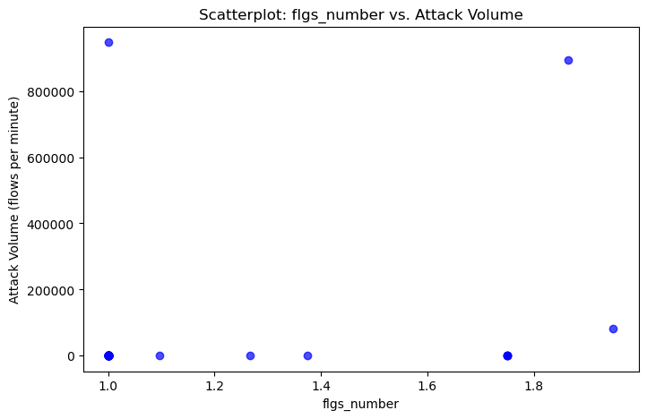

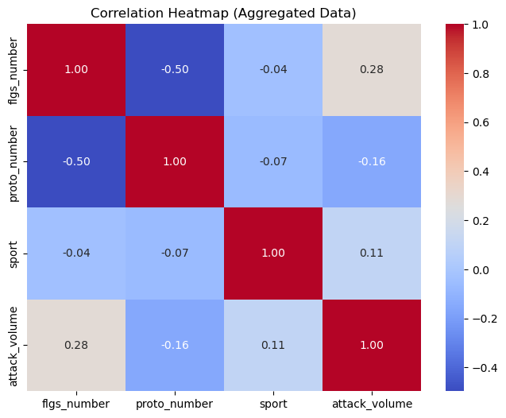

```python
# Display basic information about the aggregated dataset
print("Aggregated Dataset Info:")
aggregated.info()

# Display statistical summary of the aggregated dataset
print("\nAggregated Statistical Summary:")
display(aggregated.describe())

# Check for missing values in each column
print("\nMissing values per column in Aggregated Data:")
print(aggregated.isnull().sum())

# Visualize data with a scatterplot (example: flgs_number vs. attack_volume)
plt.figure(figsize=(8, 5))
plt.scatter(aggregated['flgs_number'], aggregated['attack_volume'], alpha=0.7, color='blue')
plt.title('Scatterplot: flgs_number vs. Attack Volume')
plt.xlabel('flgs_number')
plt.ylabel('Attack Volume (flows per minute)')
plt.show()

# Visualize correlations with a heatmap
corr_agg = aggregated[['flgs_number', 'proto_number', 'sport', 'attack_volume']].corr()
plt.figure(figsize=(8, 6))
sns.heatmap(corr_agg, annot=True, cmap='coolwarm', fmt=".2f")
plt.title('Correlation Heatmap (Aggregated Data)')
plt.show()
```

## Experiment 1: Pre-processing

After exploring the data, we need to clean and prepare it for modeling. In this step, we:

- Convert the `stime` column (Unix timestamp) into a proper datetime format.
- Convert `sport` into a numeric format to avoid mixed types.
- Create a new column `minute` by flooring the datetime to the nearest minute.
- Aggregate the data by `minute`, calculating the mean values for features (`flgs_number`, `proto_number`, `sport`) and counting the number of flows (using `pkSeqID`) to define our target variable `attack_volume`.

This pre-processing ensures our data is in a suitable format for building our regression model.

```python
# Convert 'stime' to datetime (assuming it's a Unix timestamp)
df['stime'] = pd.to_datetime(df['stime'], unit='s')

# Convert 'sport' to numeric (in case it's not already)
df['sport'] = pd.to_numeric(df['sport'], errors='coerce')

# Create a new column 'minute' by flooring the time to the nearest minute
df['minute'] = df['stime'].dt.floor('T')

# Aggregate data by minute:
# - Compute mean of 'flgs_number', 'proto_number', 'sport'
# - Count flows (using 'pkSeqID') as attack_volume
aggregated = df.groupby('minute').agg({
    'flgs_number': 'mean',
    'proto_number': 'mean',
    'sport': 'mean',
    'pkSeqID': 'count'
}).rename(columns={'pkSeqID': 'attack_volume'}).reset_index()

print("Aggregated data (first 5 rows):")
display(aggregated.head())
```

```
Aggregated data (first 5 rows):
```

|  | minute | flgs_number | proto_number | sport | attack_volume |
| --- | --- | --- | --- | --- | --- |
| 0 | 2018-05-15 00:27:00 | 1.75 | 1.750000 | 7961.625000 | 8 |
| 1 | 2018-05-15 00:28:00 | 1.00 | 2.000000 | -1.000000 | 1 |
| 2 | 2018-05-15 00:30:00 | 1.00 | 2.000000 | 12993.750000 | 4 |
| 3 | 2018-05-15 00:31:00 | 1.00 | 2.333333 | 19665.666667 | 3 |
| 4 | 2018-05-15 00:32:00 | 1.00 | 2.884615 | 35205.153846 | 26 |

## Experiment 1: Modeling

For our first experiment, we build a baseline linear regression model. We use three key features from our aggregated dataset:

- **flgs_number** (mean flow state flags)
- **proto_number** (mean protocol number)
- **sport** (mean source port)

Our target variable is **attack_volume** (number of flows per minute). We split the data into training and testing sets and then train a linear regression model using Scikit-learn.

```python
# Define features and target for baseline modeling
X_agg = aggregated[['flgs_number', 'proto_number', 'sport']]
y_agg = aggregated['attack_volume']

# Split data into training and testing sets (80/20 split)
X_train, X_test, y_train, y_test = train_test_split(X_agg, y_agg, test_size=0.2, random_state=42)

# Build and train the linear regression model
lr_model = LinearRegression()
lr_model.fit(X_train, y_train)

# Predict on the test set
y_pred = lr_model.predict(X_test)

# print RMSE
rmse = np.sqrt(mean_squared_error(y_test, y_pred))
print(f"Baseline Linear Regression RMSE: {rmse:.2f}")
```

```
Baseline Linear Regression RMSE: 80456.24
```

## Experiment 1: Evaluation

After training our baseline linear regression model, we evaluate its performance by predicting the attack volume on the test set. We use the Root Mean Squared Error (RMSE) as our evaluation metric. RMSE gives us a measure of the average prediction error in the same units as our target variable.

A high RMSE indicates that the model is not capturing the data's complexity well, setting a benchmark for further experiments.

```python
# Predict on the test set using the baseline model
y_pred = lr_model.predict(X_test)

# Evaluate the model using RMSE
rmse = np.sqrt(mean_squared_error(y_test, y_pred))
print(f"Baseline Linear Regression RMSE: {rmse:.2f}")
```

```
Baseline Linear Regression RMSE: 80456.24
```

## Experiment 1: Baseline Linear Regression Model Summary

In this experiment, we developed a baseline model to predict DDoS attack volume (defined as the number of network flows per minute) using aggregated data. The key steps and insights from this experiment are summarized below:

### Steps Involved:

1. **Data Aggregation and Pre-processing:**
   - **Conversion:** We converted the `stime` column from a Unix timestamp to a datetime format.
   - **Time Flooring:** The datetime values were floored to the nearest minute to create a new column, `minute`.
   - **Aggregation:** We aggregated the flow-level data by minute, counting the number of flows (using `pkSeqID`) to create the target variable `attack_volume`. Additionally, we computed the mean values for important features like `flgs_number`, `proto_number`, and `sport`.
2. **Feature Selection & Data Splitting:**
   - **Feature Selection:** We selected three key aggregated features: `flgs_number`, `proto_number`, and `sport`.
   - **Data Splitting:** The dataset was split into training (80%) and testing (20%) sets to allow for unbiased model evaluation.
3. **Model Building:**
   - We built a baseline linear regression model using Scikit-learn's `LinearRegression`.
   - The model was trained on the training set and then used to predict the attack volume on the test set.
4. **Model Evaluation:**
   - The performance of the model was evaluated using the Root Mean Squared Error (RMSE).
   - The baseline linear regression model achieved an RMSE of **80,456.24**, which is relatively high.

### Insights:

- **High RMSE:** The high RMSE indicates that the baseline model struggles to capture the complex patterns in the data. This suggests that the selected features may not be sufficient or that the relationship between the features and the attack volume might be more complex than a simple linear model can capture.
- **Benchmark Establishment:** This baseline performance serves as a benchmark for subsequent experiments. In further experiments, we explore additional features (such as time-based variables) and alternative modeling techniques (e.g., Ridge Regression) to improve prediction accuracy.
- **Next Steps:** The findings from this experiment underscore the need for additional feature engineering and regularization to better model the intricacies of DDoS attack traffic.

Overall, Experiment 1 provided a starting point and established the groundwork for further model refinement and experimentation.

## Experiment 2: Data Understanding

In this experiment, we explore whether time-based features can help improve our model. We suspect that the hour of the day and the day of the week may have an impact on attack volume. To investigate this, we first extract these features from our aggregated `minute` column.

Before incorporating them into our model, we review the enhanced aggregated dataset to see the distribution of the new features and verify that they make sense.

```python
# Extract hour and day_of_week from 'minute'
aggregated['hour'] = aggregated['minute'].dt.hour
aggregated['day_of_week'] = aggregated['minute'].dt.dayofweek

# Display the first few rows to inspect the new features
display(aggregated.head())
```

|  | minute | flgs_number | proto_number | sport | attack_volume | hour | day_of_week |
| --- | --- | --- | --- | --- | --- | --- | --- |
| 0 | 2018-05-15 00:27:00 | 1.75 | 1.750000 | 7961.625000 | 8 | 0 | 1 |
| 1 | 2018-05-15 00:28:00 | 1.00 | 2.000000 | -1.000000 | 1 | 0 | 1 |
| 2 | 2018-05-15 00:30:00 | 1.00 | 2.000000 | 12993.750000 | 4 | 0 | 1 |
| 3 | 2018-05-15 00:31:00 | 1.00 | 2.333333 | 19665.666667 | 3 | 0 | 1 |
| 4 | 2018-05-15 00:32:00 | 1.00 | 2.884615 | 35205.153846 | 26 | 0 | 1 |

## Experiment 2: Pre-processing

After gaining insights from our data, we prepare our new feature set. We now include the additional time-based features (`hour` and `day_of_week`) along with our original features (`flgs_number`, `proto_number`, `sport`).

This step ensures that our model can consider temporal patterns that might influence the attack volume.

```python
# Define a new feature set including the time-based features
X_feat = aggregated[['flgs_number', 'proto_number', 'sport', 'hour', 'day_of_week']]
y_feat = aggregated['attack_volume']

# Split the data into training and testing sets (80% training, 20% testing)
X_train2, X_test2, y_train2, y_test2 = train_test_split(X_feat, y_feat, test_size=0.2, random_state=42)
```

## Experiment 2: Modeling

With our enhanced feature set ready, we build a new linear regression model. This model now leverages the time-based features alongside the original aggregated features. My goal is to see if the temporal information improves our ability to predict the attack volume.

```python
# Build and train a new linear regression model
lr_model2 = LinearRegression()
lr_model2.fit(X_train2, y_train2)
```

```
LinearRegression()
```

## Experiment 2: Evaluation

After training the enhanced model, we evaluate its performance using the test set. We again use the Root Mean Squared Error (RMSE) as our metric.

In this experiment, the model with time-based features achieved an RMSE of **177,168.93**, which is significantly higher than the baseline RMSE. This suggests that simply adding the hour and day_of_week may have introduced noise or that these features require further transformation or tuning to be useful. Run the code below to get this result.

```python
# Predict on the test set using the enhanced feature model
y_pred2 = lr_model2.predict(X_test2)

# Calculate and print RMSE for the enhanced model
rmse2 = np.sqrt(mean_squared_error(y_test2, y_pred2))
print(f"Linear Regression with time-based features RMSE: {rmse2:.2f}")
```

```
Linear Regression with time-based features RMSE: 177168.93
```

## Experiment 2: Feature Engineering Summary

In Experiment 2, we aimed to improve the predictive performance of our model by incorporating time-based features derived from the `minute` column. Specifically, we extracted the following new features:

- **Hour:** The hour of the day, which could capture diurnal patterns in network activity.
- **Day of Week:** The day of the week, which might reflect differences in network traffic patterns on weekdays versus weekends.

### Process:

1. **Feature Extraction:**
   - We extracted the `hour` and `day_of_week` from the `minute` column.
   - These features were added to our original set of aggregated features (`flgs_number`, `proto_number`, `sport`).
2. **Data Splitting:**
   - We split the enhanced dataset into training (80%) and testing (20%) sets.
3. **Model Building and Evaluation:**
   - A new linear regression model was built using the enhanced feature set.
   - The model was trained on the training set and evaluated on the testing set.
   - The performance was measured using the Root Mean Squared Error (RMSE).

### Results:

- The linear regression model with the additional time-based features achieved an RMSE of **177,168.93**.

### Interpretation:

- **Increased RMSE:** The significant increase in RMSE, compared to the baseline model (which had an RMSE of 80,456.24), indicates that the inclusion of the time-based features did not improve model performance. In fact, it introduced more variability or noise, possibly because:
  - The new features may not have a straightforward linear relationship with attack volume.
  - The additional temporal information might require more sophisticated modeling or further preprocessing (e.g., normalization, encoding, or interaction terms) to capture the underlying patterns effectively.
- **Next Steps:**
  - Further investigation is needed to determine whether different representations of time (or even non-linear transformations) might better capture the effect of time on attack volume.
  - Alternatively, exploring other modeling approaches or feature selection techniques could help identify the most informative features.

Overall, Experiment 2 underscores the importance of careful feature engineering and model tuning when attempting to incorporate additional information into predictive models.

## Experiment 3: Data Understanding

In this experiment, we revisit our original aggregated dataset. We use the same features from Experiment 1:

- **flgs_number:** Average flow state flag numeric value.
- **proto_number:** Average numeric representation of protocol.
- **sport:** Average source port number.

We aim to understand if regularization can help us better model the data by controlling for overfitting. Ridge Regression, which adds a penalty term to the model coefficients, may improve our predictions compared to the baseline linear regression.

```python
# For this experiment, we reuse our aggregated features from Experiment 1.
display(aggregated[['flgs_number', 'proto_number', 'sport', 'attack_volume']].head())
```

|  | flgs_number | proto_number | sport | attack_volume |
| --- | --- | --- | --- | --- |
| 0 | 1.75 | 1.750000 | 7961.625000 | 8 |
| 1 | 1.00 | 2.000000 | -1.000000 | 1 |
| 2 | 1.00 | 2.000000 | 12993.750000 | 4 |
| 3 | 1.00 | 2.333333 | 19665.666667 | 3 |
| 4 | 1.00 | 2.884615 | 35205.153846 | 26 |

## Experiment 3: Pre-processing

Since we're using the same aggregated dataset from Experiment 1, no additional pre-processing is needed for this experiment. We will continue using the original feature set:

- **X_agg:** Includes `flgs_number`, `proto_number`, and `sport`.
- **y_agg:** The target variable, `attack_volume`.

The data is already split into training and testing sets in Experiment 1, which we will reuse here.

```python
# Define features and target from the aggregated dataset
X_agg = aggregated[['flgs_number', 'proto_number', 'sport']]
y_agg = aggregated['attack_volume']

# For consistency, we re-split the data if needed (using the same split as Experiment 1)
X_train, X_test, y_train, y_test = train_test_split(X_agg, y_agg, test_size=0.2, random_state=42)

# Display the shapes of the training and testing sets
print("Training set shape:", X_train.shape)
print("Testing set shape:", X_test.shape)
```

```
Training set shape: (56, 3)
Testing set shape: (14, 3)
```

## Experiment 3: Modeling

We now build a Ridge Regression model using the same feature set from Experiment 1. Ridge Regression adds a regularization penalty to the loss function, which helps prevent overfitting by discouraging large coefficients. This experiment tests whether regularization can yield better predictions compared to our baseline linear regression.

```python
# Build and train the Ridge Regression model on the original aggregated features
ridge_model = Ridge(alpha=1.0)  # alpha is the regularization strength; you can experiment with this value.
ridge_model.fit(X_train, y_train)
```

```
Ridge()
```

## Experiment 3: Evaluation

After training the Ridge Regression model, we evaluate its performance by predicting the attack volume on the test set and calculating the Root Mean Squared Error (RMSE). Lower RMSE values indicate better predictive performance.

Our Ridge Regression model achieved an RMSE of **59,783.33**, which is a significant improvement over the baseline linear regression model's RMSE of **80,456.24**. This suggests that regularization helped stabilize the model and reduce overfitting. Again, run the code below to get these results!!

```python
# Predict on the test set using the Ridge Regression model
y_pred_ridge = ridge_model.predict(X_test)

# Calculate and print RMSE for Ridge Regression
rmse_ridge = np.sqrt(mean_squared_error(y_test, y_pred_ridge))
print(f"Ridge Regression RMSE (original features): {rmse_ridge:.2f}")
```

```
Ridge Regression RMSE (original features): 59783.33
```

## Impact

Accurate prediction of DDoS attack volume can have significant implications for network security:

- **Positive Impacts:**
  - **Proactive Defense:** Improved predictions enable network administrators to allocate resources more efficiently and mitigate attacks before they cause damage.
  - **Cost Efficiency:** Accurate forecasting may help avoid over-provisioning resources during an attack.
  - **Enhanced Network Resilience:** Early warnings can minimize downtime and improve overall network stability.
- **Ethical Considerations and Risks:**
  - **Model Dependence:** Over-reliance on model predictions might lead to false positives/negatives if the model doesn’t adapt to evolving attack strategies.
  - **Data Bias:** The training data might contain biases, which can propagate into the predictions.
  - **Privacy:** Handling network data requires stringent measures to ensure sensitive information remains protected.

## Conclusion

Overall, this iterative process underscored the importance of data pre-processing, feature selection, and model regularization in predictive analytics for network security.

## References

- Kaggle: [DDoS Botnet Attack on IoT Devices Dataset](https://www.kaggle.com/datasets/siddharthm1698/ddos-botnet-attack-on-iot-devices)
- Scikit-learn documentation: [LinearRegression](https://scikit-learn.org/stable/modules/generated/sklearn.linear_model.LinearRegression.html), [Ridge Regression](https://scikit-learn.org/stable/modules/generated/sklearn.linear_model.Ridge.html), [PCA](https://scikit-learn.org/stable/modules/generated/sklearn.decomposition.PCA.html)
- Draper, N. R., & Smith, H. (1998). *Applied Regression Analysis*.

## Code

All code used in this project is provided within this notebook. For further details or questions, please refer to the code cells above.